# R-LAdies+ feat. useR! 2021

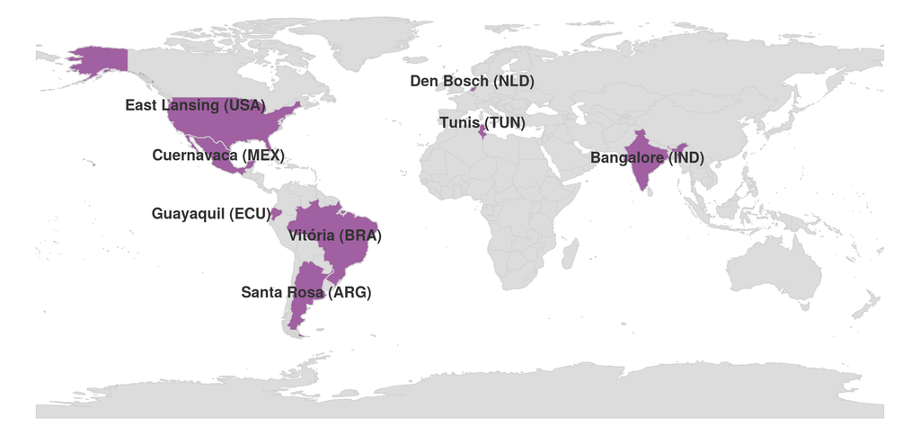

We are R-Ladies+ with different languages, accents, ethnicities, backgrounds, and experiences. However we not only speak the same computational language but we also agreed that being part of R-Ladies+ changed our lives. We strongly believe that the community plays an important role in our personal development, learning, and teaching. Because of that we wanted to share our experiences and invite people from different backgrounds to go to the conference and engage within R-Ladies+ communities. Hence, we all co-organized a meetup with a line-up of incredible panelists.

The meetup took place in the afternoon/night of April 28th (and for some the early morning of the 29th). We got together to hear from the amazing: Jonelle Villar (R-Ladies Bergen), Haifa Ben Messaoud (R-Ladies Tunis), Adithi Upadhya (R-Ladies Bangalore), Zulemma Bazurto Blacio (R-Ladies Guayaquil), Beatriz Milz (R-Ladies São Paulo), Joselyn Chávez (R-Ladies Cuernavaca), Janani Ravi (R-Ladies East Lansing). Jonelle, with the zoom background of the cake from 20th R-Consortium anniversary started the panel, saying that today the #rstats community is moving in a promising direction that allows room for all voices. This is not something that we simply say, the community is committed and promoting actions for the inclusion of different voices. Twenty years ago, one couldn’t imagine a room full of such a diverse crowd as we had on that day. Haifa came next, sharing her journey creating the Tunis chapter and reinforcing how being part of R-Ladies+ communities made her believe in herself in a way it was possible before. Adithi, as Haifa, also told us how it was to create a new chapter from the beginning and how she ended being part of the useR2021 team. Adithi made clear how useR2021 evolved from being held at one place to being a global conference with volunteers from almost all different time zones. The quality of content is so carefully picked and a lot of time and energy is spent on friendly for all time zones and areas of interest. Zulemma brought not only a different voice, but a language: her speech was entirely in Spanish (which is one of the official languages of useR! 2021). One of the co-organizers of the meetup, Andrea Sánchez-Tapia, provided a simultaneous translation in the zoom chat. Zulemma told us her journey as a statistician and how she discovered that her goal to democratize the learning of statistics was connected to R communities and R-Ladies actions. Zulemma has attended global R conferences and she reinforced that useR, a conference organized by R users to R users is a welcoming and empowering place. Beatriz shared her experience as being part of useR 2019 because of a diversity scholarship. Beatriz native language is Portuguese, and in Portuguese the expression for a life-changing experience is called: divisor de águas (watershed in English). Every body of water has a watershed and we hope that every person that is part of an R community experiences a life-changing experience to have their own watershed. Joselyn shared her experience in her local chapter, Cuernavaca (Mexico). Joselyn illustrated with the mexican experience how R-Ladies chapters are not isolated from each other. The mexican chapters interact a lot and they grow together as a community. Joselyn is part of the accessibility team at useR2021 and she showed how the conference is taking action and working hard to build an inclusive environment for everybody. Last but not least, we had the speech of Janani. Janani founded the first R-Ladies chapter in Michigan USA and has been an important voice in the useR program committee. Janani showed how the conference is being built by so many people and all the effort in making diversity a crucial part of it and not only a statement.

Being at the meetup was inspiring in so many ways. We all left wanting to go to the conference so badly. We left with the certainty that working to build local, regional and global interactions among R communities is life-changing to all of us as individuals but a much a bigger change if we think about the #rstats communities.

In the end, our message is simple and radical, and in the words of Jonelle Villar:

> My message for the people attending the useR!2021 virtual conference: Diversity is our super-power! I have no doubt that the next cake to be prepared for the next R-Consortium anniversary will have plates and forks for all.

### Resources

- Welcome presentation made by Sara Mortara [here](https://saramortara.gitlab.io/rladies_user/#1).
- Beatriz Milz’s presentation [here](https://beatrizmilz.github.io/slidesR/R-Ladies_and_useR_meetup/) and key points [here](https://github.com/rladies-eastlansing/2021-rladies_user/blob/main/speeches/beatriz_milz.md)
- Jonelle Villar’s speech [here](https://github.com/rladies-eastlansing/2021-rladies_user/blob/main/speeches/jonelle_villar.md)
- Adithi Upadahya speech [here](https://github.com/rladies-eastlansing/2021-rladies_user/blob/main/speeches/adithi_upadhya.md)